# Introduction

Empirical legal research has been slowly but surely finding it’s outside the predominant US context. Historically though most of the empirical studies have been conducted in the US, especially the Supreme Court, context [such as @boydUntanglingCausalEffects2010; @carrubbaWhoControlsContent2012; @epsteinWhyWhenJudges2011]. We now know that judgments are what judges had for a breakfast. Put less pompously, there are many theories and approaches for explanation of judicial behavior [@posnerHowJudgesThink2010]. What we do not know is the extent to which these theories and explanations carry over to other legal systems and context.

In our article, we set out to conduct an empirical research into the circumstances of disagreement on a court bench, more specifically whether Czech constitutional justices behave strategically in when and under what circumstances they dissent and whether there is an interplay between the behavior at different institutional level within the Czech Constitutional Court (“CCC”).

Our research is loosely inspired by a similar research by @epsteinWhyWhenJudges2011, who studied under which circumstances do US judges generally dissent. More specifically, they built a formal economic model based on the strategic account of judicial behavior. In particular, they tested the dependence of dissent rate on workload, the dependence of dissent rate on size of courts, the dependence of dissent rate on the ideological distance, and the dependence of length of majority argumentation on the presence of a dissenting opinion. In our study, we test our hypotheses adopted to the CCC context that are nonetheless based on similar theoretical grounds.

We adapt the theories constructed in the US context to the civil law and Czech judiciary contexts. We test whether the length of majority argumentation depends on the presence of one or more dissents, whether the workload of a judge affects their dissenting behavior, whether the dissenting behavior of judges changes at the start and end of their terms, and, lastly, whether relationships formed during the plenary sessions, as posited by the Czech legal scholarship, carry over to 3-member panel proceedings.

We find that a dissent imputes costs on the majority that produces longer arguments to address a dissent. The effect is stronger the more disagreement there is on the bench. We find that the workload of a judge does decrease the likelihood of dissent. Moreover, our analysis corresponds to the theory that dissents bring about significant collegiality costs for the dissenter. Lastly, we reveal similar trends in behavior of judicial coalitions from plenary proceedings also in the 3-member panel proceedings.

Our article proceeds as follows. We start out with a theory. We explain the main differences between the expectations based on the theory in the CCC context in comparison to the SCOTUS context and based on that we draw the hypotheses for the empirical part. We briefly explain the choice of our broad methodological framework: the Bayesian statistics. We proceed to test the hypotheses in empirical part divided into sections one per each hypothesis. We discuss the pitfalls of our research and potential room for improvement afterwards. Lastly, we conclude with a summary of our findings.

# Theory

In general, there are multiple accounts of behavior of judges’. The first that had dominated until ~the end of 20th century posited that judges are policy oriented. A lot of research has been conducted on whether, how and to what extent do judges indeed seek to advance the policies they desire [@berdejoElectoralCyclesUS2017; @clarkLocatingSupremeCourt2010; @dworkinPoliticalJudgesRule1980; @kastellecEmpiricallyEvaluatingCountermajoritarian2016; @moyerJudicialInnovationSexual2012].

However, as of recently, the perspective on judges has shifted. Judges are now allegedly strategic and rational actors. One of the early pioneers of this approach @posnerWhatJudgesJustices1993 presents a simple model of judicial utility as function mainly of income, leisure and judicial voting. Further research followed the Posner mode and presented alternative models of judicial utility (based on economic psychology @foxallWhatJudgesMaximize2004). Replacing the policy oriented approaches, which hold judges to pursue political policy oriented goals, researchers now focus more on their self-interest in terms of career progression, higher income, or lesser workload [@carrubbaWhoControlsContent2012; @epsteinStrategicRevolutionJudicial2000]. @posnerHowJudgesThink2010 presents nine theories of approach for judicial behaviour, from which we mostly draw on the economical and sociological theory. Economic theory of judicial behaviour treats the judges as a rational, self-interested, utility maximizer and sociological theory of judicial behaviour incorporates factors of strategic calculation, emotion, and group polarization.

@epsteinWhyWhenJudges2011 based their theory of dissents on the strategic-economic framework of self-interested strategically motivated judges. They presume that judges “leisure preferences, or, equivalently, effort aversion, which they trade off against their desire to have a good reputation and to express their legal and policy beliefs and preferences (and by doing so perhaps influence law and policy) by their vote, and by the judicial opinion explaining their vote, in the cases they hear.” The benefits of a dissenting opinion are the potential to undermine the majority opinion when the dissent is influential and the enhanced reputation that the judge enjoys. The dissenting opinion may be cited in the future by other judges or publicly analysed by legal scholars.

The theories they presume and hypotheses they test rest on this framework: in the policy-oriented framework, it would not make sense to expect judges to dissent less as their workload increases. They would still seek a way to advance their political agenda and research has shown that dissenting opinions usually correspond to exactly just that [@clarkLocatingSupremeCourt2010]. However, in the strategic account, the higher the workload of a judge, the more pressing the effort costs of a dissent. Similarly, if a dissenting opinion imputes costs on the majority, we can theoretically expect it to respond to the dissent with a more thorough or detailed argumentation in the majority opinion.

In our study, we are empirically verifying such theoretical presumptions taken from the US context and transplanted to the context of the CCC. There are obstacles that a researcher faces when conduct an original US-inspired research design in European context.

Firstly, a major obstacle in conducting and carrying the US research elsewhere is data availability. We narrow our object of analysis to the CCC because there is the largest variation in the dissenting behavior (unlike on the Supreme Administrative Court). While there is not yet a full fledged dataset on the CCC [like the SCOTUS or CJEU @brekkeCJEUDatabasePlatform2023], we have managed to build a complete dataset on the CCC, which includes complete text corpus, metadata about cases and background information of the judges. Typically for the US context, @epsteinWhyWhenJudges2011 include in their analysis the ideological distance between judges but they are far from the only ones [@berdejoElectoralCyclesUS2017; @boydUntanglingCausalEffects2010; @carrubbaWhoControlsContent2012; @clarkLocatingSupremeCourt2010; @kastellecEmpiricallyEvaluatingCountermajoritarian2016; @segalIdeologicalValuesVotes1995]. The ideological distance serves as one of the explanatory variables for dissent aversion. The measures of ideological position of judges mainly rely on information about their voting behavior. Regrettably such information is in continental legal systems typically not made public: the votes in cases are kept secret. Therefore, it is near impossible to construct a measure of the political position of judges without knowing how they voted in each case.

Secondly, we utilize variation of different institutional settings rather than a in between courts variation between SCOTUS and Federal Courts. The CCC is structured so that it can either decide cases in 3-member panels or a plenary session. Moreover, we are able to use the variation of a judge rapporteur. To apprehend the institutional variation, we interpose a short section on the CCC institutional setup and the difference in comparison to the SCOTUS, which has repercussions on our theory.

The CCC consists of 15 judges: a Chairman, two Vice-chairmains and twelve judges who are members of the permanent 3- member panels consisting of three judges. The CCC justices are elected for 10 years and the appointment process is akin to that of SCOTUS: the President proposes a candidate that is confirmed by the Czech Senate.

The CCC is currently entering its fourth decade, having been established in 1993, with 3 “generations” of judges having been rotated so far with the fourth term of the CCC being just around the corner. Concerning the institutional setup, the CCC can decide a case in two formations: there are four 3-member panels and a plenum, which attracts procedurally specified cases. Thus, the size of the deciding body varies within the court. So does the type of cases that get assigned to either type of body.

Regarding the specific theory and hypotheses we zero in on, @epsteinWhyWhenJudges2011 find the strategic aspect of dissenting in how a judge squares their decision to either dissent or to avert a dissent based on the costs and benefits of a dissent. The authors claim that “[s]ince writing a dissenting opinion requires effort, which is a cost, a judge will not dissent unless he anticipates a benefit from dissenting that offsets his cost.” The majority also accrues costs from dissenting. In their words: “[d]issenting imposes an effort cost on the majority as well and sometimes a reputation cost too, if the dissenting opinion criticizes the majority force- fully. To minimize the dissenter’s criticisms and retain the vote of the other judge in the majority (in a panel of three judges, the normal number of judges who decide a case in the federal courts of appeals), the author of the majority opinion often will revise his opinion to meet, whether explicitly or implicitly, the points made by the dissent.” A following hypotheses can be distilled:

H<sub>1</sub>: The presence of dissent positively affects the length of the majority argumentation.

The room for the dissenting judge and the majority to address each other differs between the two bodies. Based on our internal insight, there is less back and forth interplay between the judges, more akin to the SCOTUS context, and most of the communication is handled remotely in the panel proceedings, whereas the plenum meets regularly to discuss the cases in person. Despite that, procedurally speaking, the process of generating dissents is the same. In both cases, the rapporteurs are informed about the outcome of the vote, which is filed in the voting record. The dissenting opinion is then sent to the judge rapporteur before the decision is announced, as it cannot be added until after the announcement. It is important to note that judges have the possibility, not the obligation, to dissent. In other words, there is room for judges to give way to strategic considerations.

To advance the theory further, what we believe that a presence of a dissenting opinion truly captures is the expressed disagreement among CCC judges. Since the individual cases are debated among the judges, whether in person or remotely, it is possible to observe which side a judge takes during the discussion before the final vote. The judges have in either deciding body ample room to voice their disagreement, even if they write the dissenting opinion last minute. There is no evidence that would suggest otherwise - that the normal behavior would be to remain silent until the vote and then present the majority with a dissenting opinion.[^1] Thus, technically speaking, the true explanatory variable of our theory is at all times the varying disagreement among judges.

H<sub>2</sub>: The higher the workload of a judge, the lower their likelihood of dissent.

@epsteinWhyWhenJudges2011 address the issue of collegiality costs arising for a dissenting judge: “The effort involved in these revisions, and the resentment at criticism by the dissenting judge, may impose a collegiality cost on the dissenting judge by making it more difficult for him to persuade judges to join his majority opinions in future cases.” Based on this theory, they predict and indeed empirically confirm that “dissents will be less frequent in circuits that have fewer judges because any two of its judges will sit together more frequently and thus have a greater incentive to invest in collegiality.” Put simply, the researchers compare the dissent rates between courts with differing number of members.

While it is hard for us to see how a variation between the number of members in the plenary session and 3-member panels could be isolated from a plethora of potential confounding variables, we are able to make use of the limited term of CCC judges. We test whether judges that are at the start of their term, and thus are aware that they will “sit together more frequently” invest in collegiality by averting dissents and whether when their term draws to an end, they give way to their disagreement. This presumes that the outlook of sharing the 10 year term with your colleagues at the beginning of judges’ terms increases the collegiality costs of dissenting, whereas at the end of their terms, the collegiality costs decrease with the end of the shared term looming on the horizon. We pose the research question, whether the judges’ likelihood of dissents varies across their terms as a result of differing collegiality costs. We test third hypothesis:

H<sub>3</sub>: The judges are less likely to dissent at the beginning of their dissents, whereas they are more likely to dissent at the end of their terms.

Lastly, the research on judicial coalitions at the CCC has revealed that the third period of CCC between 2013-2023 is rather polarized and that there are two big coalitions of judges that clash against each other [@chmelCoOvlivnujeUstavni2021; @smekalMimopravniVlivyNa2021; @vartazaryanSitOvaAnalyza2022]. The articles rely primarily on network analysis of the dissenting opinions in the plenary proceedings and make inferential conclusions based on a rather superficial descriptive analysis. We hypothesize that should the relationship from the plenary sessions indeed exist, they should also carry over to the 3-member panel hearings. Our hypothesis is that panels composed of judges from both coalitions will be more likely to show disagreement in the form of dissenting opinion. If this shows to be true, it would provide further evidence to the two coalition theory of the CCC [@chmelCoOvlivnujeUstavni2021; @vartazaryanSitOvaAnalyza2022; @smekalMimopravniVlivyNa2021]. The Vyhnánek article goes so far to coin the first coalition as a more left-leaning and the second as a more right-leaning, whereas we are not convinced by this label.

We test whether the presumable existence of the coalitions carry over to and have any effect on the dissenting behavior of judges in the panels. Consistent with our theoretical part, we believe that a dissenting opinion reflects disagreement on the judicial bench. Our intuition suggests that if indeed there are two coalitions in the plenary proceedings, which strongly disagree between each other, such a disagreement should, theoretically, carry over to the panel level. Our research question is thus whether judicial coalitions formed in the plenary proceedings affect the amount of disagreement and, in turn, the likelihood of dissent of a judge in 3-member panels. Our hypothesis is as follows:

H<sub>4</sub>: Having a 3-member panel composed of members of both judicial coalitions increases judges’ likelihood of a dissent.

# Method

Methodologically, we rely on regression based research design with observational data. Unfortunately, the legal environment does not lend itself easily to (quasi)experimental design.

Our study deviates in that we utilize the *Bayesian* rather than *frequentist* framework of statistics. Without delving too much into the Bayesian versus frequentist statistics, we opt for the Bayesian framework for it, we believe, reflects better our understanding of probability and scientific inquiry.[^2] There are two major differences in understanding of concepts between the two approaches towards statistics: that of role of prior knowledge and that of probability. The Bayesian framework rather than measuring the uncertainty about observed data (personified by the p-value) measures the uncertainty of the parameters of interests, given the observed data and our prior knowledge. In simple terms, the Bayesian statistician puts into doubt their conclusions about parameters of a certain model, given the observed data and their prior knowledge. Mathematically, the uncertainty is reflected in the fact that the posterior parameters are drawn from a posterior distribution of the model and are just an approximation of thereof.

The Basian computations are implemented in the R programming language and STAN software, connected via the RStan package and utilized within the tidymodels framework. We include all the model specifications and diagnoses in the appendix. In this article, we mainly focus on the output of the models and the interpretation of thereof.

The Czech Apex Court dataset used for our analysis comprises the dataset CCC decisions. The Czech Apex Court dataset includes complete database of decisions of the CCC, SAC and the Czech Supreme Court, including comprehensive metadata, text corpus, as well as additional information mined from the texts or publicly available sources, such as case references, compositions, or background information of the judges. The analysis was limited up until the end of 2022. We filtered only those decisions, where a variation in the dissenting behavior could procedurally be observed: procedural decisions were filtered out as they require unanimity among the judges and do not leave any space for disagreement.

# Model specifications and results

## H<sub>1</sub>: Effect of presence of dissenting opinion on the length of majority argumentation

### Model specification

In the original study, the authors collected roughly 446 SCOTUS and 1025 US court of appeals decisions. They then create regression models to see whether the presence of at least one dissenting opinion affected the length of the majority opinion. Based on application of their model to the SCOTUS data, the trio of authors found a statistically significant and positive relationship between presence of at least two dissenting opinions and the length of the majority decision, as well as control variable - the importance of the case. While we are aware that the importance or salience of a case is probably the key confounding variable, measuring as a post-treatment amount of references of that decision might introduce further bias

#### Conceptualizing importance of a case as a control variable

In general, when utilizing a regression design with observational data, as is our case, a researcher must satisfy certain conditions to be able to interpret regression results as a causal relationship. The first is the stable unit treatment value assumption (SUTVA) and the other is usually referred to as *conditional independence assumption*. This condition requires that the assignment of treatment T to unit *i* is independent of any covariates *X* of the unit *i* that also influence their outcome *Y*. The CIA may be formalized as follows:

$${Y_{1i}, Y_{0i}} {\bot} T_{i}|X_{i}$$

The notation follows the potential outcomes framework. {Y<sub>1i</sub>, Y<sub>0i</sub>} refer to the outcome of a unit i with or without treatment, in our case the presence of at least one dissenting opinion. There are, in general, two types of causes of bias: a confounding variable, which breaks the CIA, and reverse causality. A confounding variable is such that

1. has an effect on treatment status,
2. has an effect on the outcome over and above its effect on the treatment status.

Not controlling for confounding variables causes an omitted variable bias.

While at first glance it may thus seem that researchers should throw in as many covariates as possible, that is in reality not the case. There are examples of bad or unnecessary controls that are themselves an outcome of the treatment [for a detailed discussion see @angristMostlyHarmlessEconometrics2009; @angristMasteringMetricsPath2015; @montgomeryHowConditioningPosttreatment2018]. Among them are post-treatment variables, which imply that all control variables must occur before the treatment takes place.

We believe that importance of a decision is a potential confounding variable as it clearly may impact both the length of a judgment as well as the likelihood of a dissent. However, proxying it by the number of citations in ensuing caselaw may present a bad post-treatment control variable because it occurs and is measured after the decision to dissent or not to dissent has been made. On top of the operationalization, we are not exactly sure what kind of importance is being capture - is it political or legal importance of a case? We presume that in our context, it makes more sense to control for the complexity of case, we nonetheless try to capture legal importance too. The *formation of the CCC* and the *number of references to CCC caselaw* are better pre-treatment proxies for the *legal* importance and complexity of a decision.

Institutionally, the CCC can decide cases either in 3-member panels or in the whole plenary session. Put simply, we assume that more important cases are decided in plenary rather than 3-member panel formation. The plenary is more likely to rule on merits and its decisions are, therefore, on average longer. Moreover, the dissent rate in the plenary decisions is also higher. Thus, the formation of the CCC reflects the importance of the case being decided, which has a confounding potential.

We confirm our intuition by comparing our metric of importance of a case to Epstein’s metric in the CCC context. While plenary decisions make up only 1.5 % of all CCC decisions, they make up 15 % references in the CCC caselaw. Unlike the Epstein metric, our metric is in any case determined before the decision to dissent or not to dissent is made. Thus, in our model, we’re including a dummy variable for the formation of a court, i.e., whether the decision was made in a 3 member panel or a full court plenary.

Lastly, we wanted to address the complexity of a case. We believe it to be another potential confounding variable: a more complex decision will be undoubtably on average longer and it gives more room for disagreement to arise. One way to measure complexity would be to how many legal sources a legal decision refers. We presume that the number of references to the Constitution, the main benchmark of the CCC’s constitutinal review, is rather invariable and does not necessarily reflect complexity. A very complex case can pertain only one paragraph of the very vaguely and abstractly drafted Constitution. Moreover, other potential ways to measure complexity of a case would prove hard to operationalize - such as the number of reviewed laws in the abstract review. Because we could automatically identify all the self-references within the CCC caselaw, we included the number of self-references in any given CCC decision as a control variable for the complexity of a case.

Our final model thus looks as follows:

$$W_{argument} = f(one\:dissent + more\:dissents + formation +
number\:of\:selfreferences)$$
Building on the theory, in our model, we included the number of words of the court argument part of a decision as the outcome variable. Regarding the explanatory variables, we opted for (1) a dummy variable signifying a presence of one dissent as an explanatory variable, (2) a dummy variable signifying a presence of two or more dissents as an explanatory variable, (3) the formation of the CCC as a control variable, (4) the number of self-references. We code the one and two or more dissents separately because we believe a higher number of dissents implies a higher degree of disagreement. We lump the two and more dissents into variable because the number of decisions with more than two of dissents is few and far between.

### Data collection

While the metadata of decisions contain information about a presence of a dissenting opinion, regrettably, the CCC decisions are not neatly split up like their SCOTUS counterparts. The text of the decision contains both the majority opinion as well as the dissent without any clear boundary from other parts of the structure. That is why we relied on machine learning to extract the information about presence, position of dissenting opinion as well as length of the majority argumentation in the CCC decisions.

Utilizing machine learning unlocked one more avenue to further improve the original model. Instead of conceptualizing the length of the majority opinion as the whole majority opinion, we narrowed our inquiry only to the majority argumentation rather than including, for example, the heading or the facts of the case in the length of a majority opinion variable. Therefore, we believe our model better reflects the relationship between the presence of a dissent and the legal argumentation of the majority.

To extract the length of dissents and length of majority argumentation, multiple supervised classification algorithms were trained following similar structure-mining attempts within the Czech context [@eliasekAutomatickaKlasifikaceVyznamovych2020; @harastaAutomaticSegmentationCzech2019; and elsewhere @ludersProportionalityArgumentIdentification2023]. A sample of 200 decisions was manually annotated on a paragraph level. The paragraphs were then represented either as dense doc2vec vectors based on word2vec model of the whole CCC text corpus [@mikolovEfficientEstimationWord2013] or as sparse document-term-matrix with the td-idf values for each word. Positional encoding of a paragraph was added to both representations of text. Because there was a large unbalance between the classes, oversampling algorithm SMOTE was applied to balance out the dataset, which is a standard practice when working with smaller datasets [@fjelstulHowChamberSystem2021].

Our classification followed in two stages. In the first step, the dissenting opinions were classified from the rest of the decision so that the positional encoding remained consistent across all cases. Otherwise, in the decision without a dissenting opinion, usually a conclusion or court argumentation was at the end of the decision, whereas in the decisions with a dissent, the dissenting opinion was at the end of the decision. That created confusion with the positional encoding. Our first stage classification allowed us to separate the dissenting opinion from the rest of the decision and then recalculate the positional encoding for the remaining paragraphs. In the second step, the remaining text as well as the decisions that did not contain a dissenting opinion were classified into an inner structure consisting of: (1) heading, (2) verdict, (3) procedure history, (4) complainant arguments, (5) court arguments, (6) conclusion, (7) information on further legal remedies, and (8) signature.

In line with the findings of Eliasek and Lüders articles, we tested and compared three classification algorithms: - Support Vector Machines [@gandhiSupportVectorMachine2018] with the sparse td-idf representation and Gradient Boosted Decision Trees [@maklinGradientBoostingDecision2019] and Random Forests with the dense doc2vec embeddings. More complex algorithms did not provide any improvement in accuracy at the cost of higher computing costs. The benchmark for both classifiers was the zero rule, i.e., the proportion of the majority class as a zero rule classifier would presume that all occurrences are of that class and would be right the proportion amount of the time.

In the end, the XGBoost algorithm combined with the doc2vec embeddings boasted the highest benchmark values (precision, accuracy, FScore). The precision of the first stage classifier was ~86 %, above the 75 % zero rule benchmark. The precision of the second stage classifier was ~82 %, well above the 37 % zero rule benchmark. Afterwards, both classification models were trained on all annotated data and used to predict classes of the whole dataset.

### Results

We opted for a completely pooled model as the data did not contain any inherent structure (there were no clusters). We instead opted for the Negative Binomial model, which allows for relaxing the assumption of equality of variance of Y to its expected value in comparison to the Poisson model. Thus, the explanatory variable, the number of words of argumentation of the CCC *Y*

$$Y_{words} | \mu, r \sim NegBin(\mu, r)$$
As for the priors, we based the priors a cursory exploratory peak into the data. All our priors follow a normal distribution, the intercept being centered around the population mean. The remaining priors were kept uninformative, because we simply have no previous knowledge on the CCC. The negative binomial family employs a log link, therefore the resulting estimates have to be interpreted as such. The model did a resonable job of predicting the underlying data.

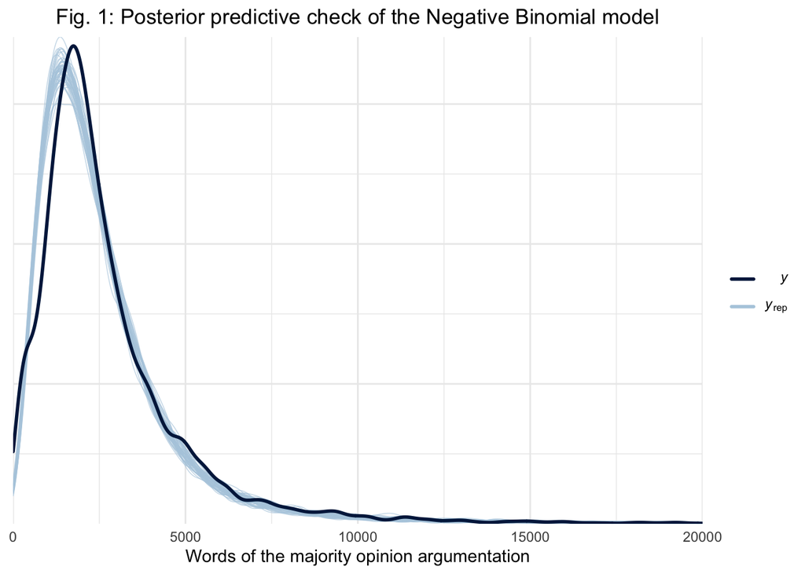

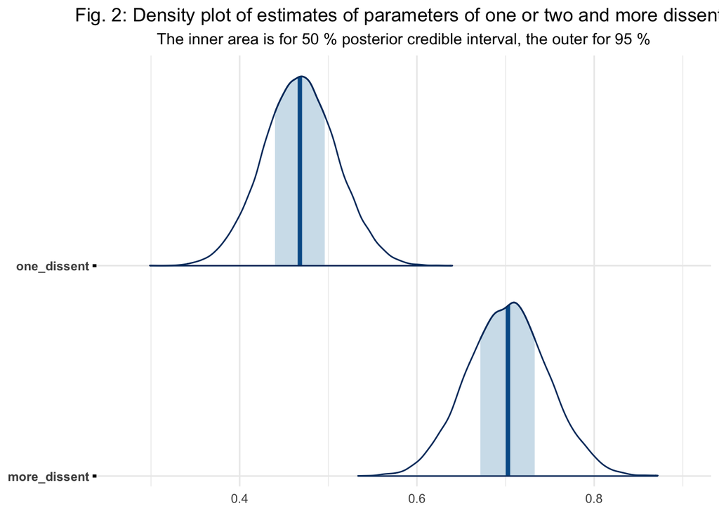

Even after controlling for all potential observable confounding variables, the already unlogged regression table looks as follows

| term | estimate | std.error | conf.low | conf.high |
| --- | --- | --- | --- | --- |
| (Intercept) | 1869.63 | 1.01 | 1841.94 | 1897.17 |
| one_dissent | 1.60 | 1.04 | 1.51 | 1.69 |
| more_dissent | 2.02 | 1.05 | 1.90 | 2.14 |
| formationPlenum | 0.82 | 1.02 | 0.80 | 0.85 |
| n_citations | 1.04 | 1.00 | 1.04 | 1.04 |

In other words, the presence of one dissent implies an average *e*<sup>0.47</sup> increase of words in the court arguments part of judgment. Put in terms of percentage, a presence of one dissent increases the length of the argumentation by 60 %. The presence of two or more dissents implies an average *e*<sup>0.7</sup> increase of words in the court arguments part of judgment. That is a staggering ~100 % increase in the length as a result of presence of two or more dissenting opinions. To this end, the result of our study is in line with the US study: a presence of dissenting opinion increases the length of the majority opinion argumentation considerably.

We believe there are two potential ways to explain this behavior. Either the majority simply takes the dissenting opinion seriously and addresses the arguments raised in them or the presence of a dissenting opinion reflects a deeper disagreement between judges that would have taken place during the deliberation. Based on our knowledge of the inner organisation of the court, the deeper disagreement explanation would fit the plenary proceedings more accurately as a more thorough debate usually takes place than in the 3-member panel proceedings. Such a substantive explanation for our findings is supported by the fact that decisions originating in the plenary proceedings are disproportionately over-represented among decisions that contain at least one dissenting opinion. This explanation is further supported by the larger effect of having 2 or more dissents over just the 1 dissent. More dissenting judges simply imply higher degree of disagreement on the bench. The latter explanation fits within our theory of conceptualizing dissent as a result of differing degree of disagreement on the bench. Be it as it may, we conclude that a dissents imputes costs on the majority.

## H<sub>2</sub>: The higher the workload of a judge, the lower their likelihood of dissent.

### Model specification

We could conceptualize the workload of a judge in multiple ways:

1. the number of cases submitted and assigned to each judge rapporteur per year (we refer to this option as the caseload)
2. the number of unfinished cases as a judge rapporteur of any judge at the time of decision in any given decision (we refer to this option as workload), 3 and 4. as the yearly rate of change of thereof.

The option 1 captures the caseload here is that of an individual judge of decisions that they have to decide and write, or the rate of change of thereof. The more cases the judges have to author each year, the busier they are.

However, it is doubtful whether that is how a judge would perceive workload. We believe our second measure captures the workload of a judge better: the number of unfinished cases that any given judge has in the moment of any given decision as a judge rapporteur. We firstly mined the compositions of panels as well as the plenary from the text of the decision. We then calculated the number of unfinished cases each judge had at the time of any given decision as a judge rapporteur using the date of submission and of decision of a case. We believe such a measure captures the perceived workload of a judge much better: a judge knowing that they have, for example, 20 in comparison to 100 decisions to draft as a judge rapporteur is how they would perceive having had more workload.

Similarly, instead of measuring dissent rate on the Constitutional court in general, we can regress the number of dissents written by each judge either per year on the caseload or we can regress the decision to dissent of any given judge on their workload. Ideally, we would measure both variables as rate of change. However, there are many observations of the number of dissents with the value of 0. In these cases, the rate of change would either be infinite or not a number (as a 0 would appear either in the denominator or numerator of the rate of change formula). Getting rid of the zeroes would imply a rather complex transformation [for a more detailed overview of the possible transformations see @hyndmanTransformingDataZeros2010].

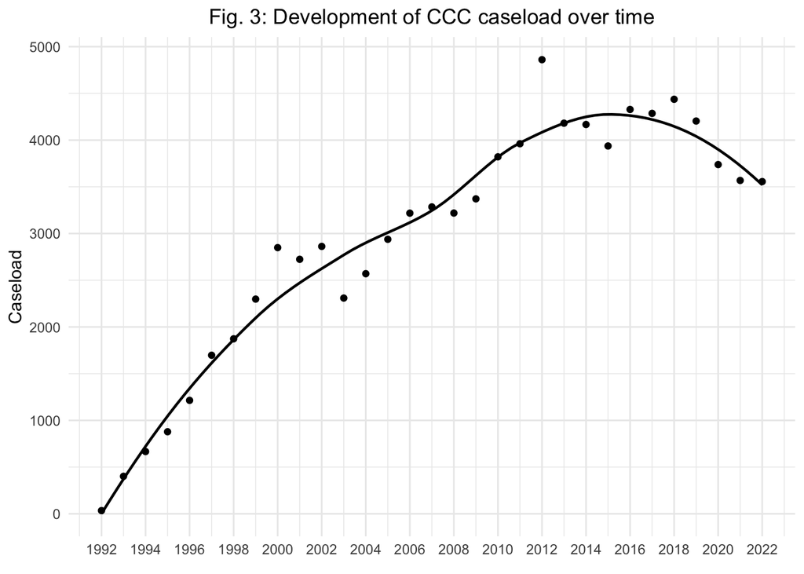

We opt for the Bayesian logistic regression model because the dependent variable is a binomial variable with 1 trial, i.e. our *Y*, the decision to dissent or not to dissent of a judge in any given decision:

$$Y | \pi \sim Bern(\pi)$$
Our model looks as follows:

$$P(dissent) = f(unfinished\:cases)$$

### Result

#### Interpreting the posterior

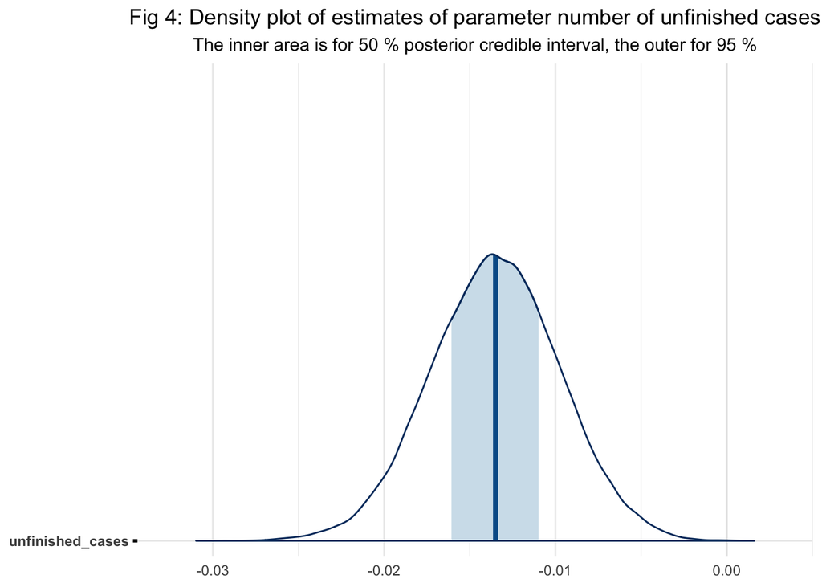

The regression table is already transformed into odds from the log odds output of the model. At first glance, the results are in line with our theoretical predictions.

| term | estimate_odds | std.error | conf.low | conf.high |
| --- | --- | --- | --- | --- |
| (Intercept) | 0.059 | 1.061 | 0.054 | 0.063 |
| unfinished_cases | 0.987 | 1.004 | 0.982 | 0.991 |

## H<sub>3</sub>: Collegiality costs of dissenting at the CCC

### Model specification

We build on our previous model. We now know that the number of dissents of a judge rapporteur follows a Poisson distribution. We use a hierarchical model pooled on the judges. We have no knowledge whatsoever about the effect of start or end of term on the number of dissents, thus, we use only weakly informative priors. We have addressed the potential sources of bias with the workload as an explanatory variable above.

$$N_{dissents} = f(start\:term + end\:term)$$

Because of the introduction of the system of bi-yearly rotations of the 3-member panels in 2016, we include in our analysis only the plenary decisions, where the composition remained relatively stable throughout the judges’ terms.

### Results

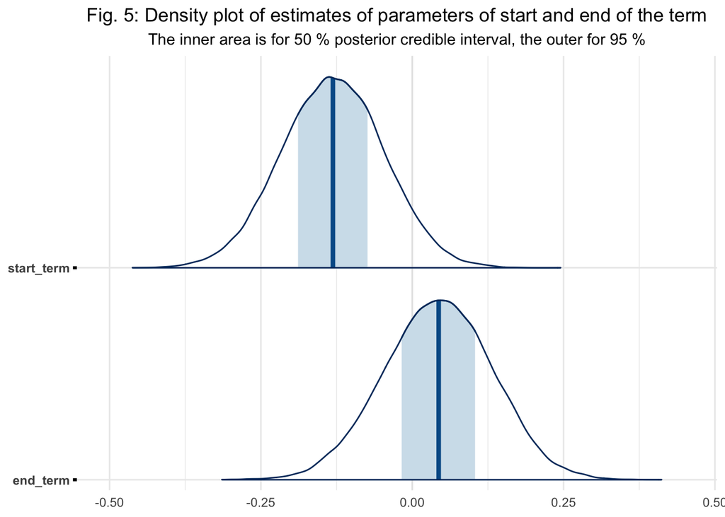

Even if we attempted to interpret the results, the results would be consistent with the original. The model reveals the trend that the judges seem to change their dissenting behavior depending on in which phase of their term do they find themselves, they would be more likely to dissent at the end and less likely at the beginning of their terms.

| term | estimate | std.error | conf.low | conf.high |
| --- | --- | --- | --- | --- |
| (Intercept) | 2.48 | 1.09 | 2.21 | 2.76 |
| end_term | 1.04 | 1.09 | 0.93 | 1.17 |
| start_term | 0.88 | 1.09 | 0.79 | 0.98 |

## H<sub>4</sub>: Judicial coalitions formed in the plenary proceedings affect judges’ likelihood to dissent in 3-member panels

We filtered the 3-member panel on merits decisions[^3] of the 3rd term CCC and coded the following dummy variables. One dummy for each coalition, if all 3 members of the panel in any given decision were members of the same coalition. On top of that, our model included one dummy variable, if one member of the panel in the minority came from the other coalition of the 2 majority judges.

$$P(dissent) = f(full\:coalition\:1 + full\:coalition\:2 +
mixed\:1\:minority + mixed\:2\:minority)$$

The assignment to panels is as good as random, thus, there is no need to control for other covariates. Because our outcome of interest, the presence of a dissent in any given decision, is a binary variable, we opted for the binomial logistic regression model. For the model, we used weakly informative priors as we have no idea about the potential effect of having the two coalitions.

### Results

The regression table is already transformed into odds from the log odds output of the model.

| term | estimate_odds | std.error | conf.low | conf.high |
| --- | --- | --- | --- | --- |
| (Intercept) | 0.03 | 21.44 | 0.00 | 1.75 |
| full_coal_1 | 0.68 | 21.60 | 0.01 | 32.89 |
| full_coal_2 | 0.00 | 2577638.25 | 0.00 | 0.05 |
| mixed_coal_1_min | 2.03 | 21.58 | 0.04 | 99.94 |
| mixed_coal_2_min | 2.12 | 21.35 | 0.04 | 104.20 |

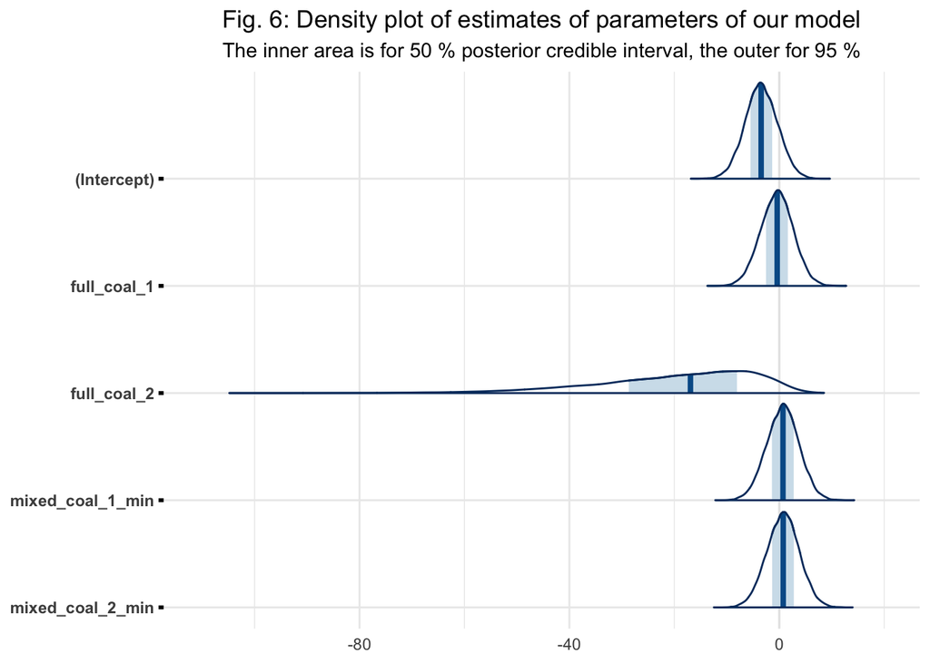

Interpreting the repercussions for theory is quite difficult, especially given the lack of data on the second and given the rather large standard errors. While we steer clear of using the language of causal relationship, the trend is clear: a panel composed of members from both coalitions from the plenary proceedings increases the disagreement on the bench. We could not confirm any heterogenous effects between the two coalitions. We also cannot exactly pin point the mechanism of the effect: Do the relationships from the plenary proceedings subsequently carry over to the 3-member panel proceedings? Is there a 2-way effect? We thus conclude rather cautiously that our data and evidence seems reasonably compatible with the explanation of Czech legal scholars, however, due to large standard errors, the evidence remains inconclusive.

# Conclusions

We attempted to transplant a research design from the US context to the European context. We had to adjust it to the extent that data availability precluded us for posing certain hypotheses or applying certain methods. Our results are inconclusive as to the potential to transfer conclusions from empirical legal research conducted in the US context elsewhere. We believe our study opens up new doors for empirical legal research, both substantively and methodologically.

Regarding the latter, the method, the prerequisite for our study was building a large dataset on the Czech Apex Court, which is to be published soon. Having a large text corpus as well as metadata and handcoded information about the judges at hand unlocks a lot of new potential research avenues, including research utilizing quantative text analysis, machine learning etc.

We’re very well aware that, on the one hand, utilizing, for example, machine learning to process large amount of court decisions in itself solves all the issues, we’re also aware that it introduces new uncertainties and inaccuracies. On the other hand, it allowed us to conduct an empirical research in an environment, in which it has not traditionally been conducted.

Our next remark addresses our research design in general: the regression analysis. We are aware that given the potential outcome frameworks, it is difficult to sustain all the assumptions of regression research design. Experimental or quasi-experimental research design such as difference-in-differences or discontinuity designs should be the golden standard of social science [@buenodemesquitaThinkingClearlyData2021]. The relative unmalleability of law in general, but rather conservative institutions such as courts in particular, leaves little space for experimental design and the general applicability of law within a legal system leaves little space for quasi-experimental design. That is not to say that it is impossible. Although we tried our best to think of and to address all potential sources of bias and whether the assumptions of the models of choice were met, we are aware of limitations of regression-based research design and therefore our conclusions should be taken with a grain of salt.

Regarding the substantive results, to us a little surprisingly, we reached very similar results as the @epsteinWhyWhenJudges2011 study. We found that a dissent opinion imposes costs on the majority that produces longer arguments to address a dissent. The effect is stronger the more disagreement there is on the bench. We find that the workload of a judge does decrease the likelihood of dissent. Moreover, although inconclusively, the dissenting behavior of a CCC judge seems to vary depending on the stage of their term. Lastly, we reveal similar trends in behavior of judicial coalitions from plenary proceedings also in the 3-member panel proceedings.

We believe those to be very interesting findings that can be further developed. While we found some clear trends, it is uncertain whether our explanation always fits the data perfectly as there are always plausible competing explanations. To this end we believe that a qualitative study utilizing interviews could shed more light to our substantive findings.[^4]

# Literature

[^1]: We are aware of one judge whose behavior resembles the description, the rest voice their disagreement openly.
[^2]: We include a longer description of our reasoning in the appendix
[^3]: At the 3-member panel level, procedural decisions have to be unanimous. Therefore, they do not leave any variation of dissenting behavior and we leave them out of the model.
[^4]: Which we are currently working on.